# Lab5

Andrew Bartnik

2023-02-07

This week’s lab is a musical lab. You’ll be requesting data from the Spotify API and using it to build k-nearest neighbor and decision tree models.

In order to use the Spotify you must have a Spotify account. If you don’t have one, sign up for a free one here: https://www.spotify.com/us/signup

Once you have an account, go to Spotify for developers (https://developer.spotify.com/) and log in. Click the green “Create a Client ID” button to fill out the form to create an app create an app so you can access the API.

On your developer dashboard page, click on the new app you just created. On the app’s dashboard page you will find your Client ID just under the header name of your app. Click “Show Client Secret” to access your secondary Client ID. When you do this you’ll be issued a Spotify client ID and client secret key.

You have two options for completing this lab.

**Option 1**: **Classify by users**. Build models that predict whether a given song will be in your collection vs. a partner in class. This requires that you were already a Spotify user so you have enough data to work with. You will download your data from the Spotify API and then exchange with another member of class.

**Option 2**: **Classify by genres**. Build models that predict which genre a song belongs to. This will use a pre-existing Spotify dataset available from Kaggle.com (https://www.kaggle.com/datasets/mrmorj/dataset-of-songs-in-spotify)

```r
library(spotifyr) #API interaction
library(tidyverse)
library(tidymodels)
library(retry)
library(rpart)
```

```r
library(rpart.plot)
library(ranger)
library(baguette)
```

Client ID and Client Secret are required to create and access token that is required to interact with the API. You can set them as system values so we don’t have to do provide them each time.

```r
Sys.setenv(SPOTIFY_CLIENT_ID = '1da3191ac7504680bbd12fd9e405957e')
Sys.setenv(SPOTIFY_CLIENT_SECRET = 'fe8c3efcd6774c108d81f239b00fa7c1')

access_token <- get_spotify_access_token() #takes ID and SECRET, sends to Spotify and receives an access token
```

> *This may result in an error:*

> INVALID_CLIENT: Invalid redirect URI

> *This can be resolved by editing the callback settings on your app. Go to your app and click “Edit Settings”. Under redirect URLs paste this: http://localhost:1410/ and click save at the bottom.* **Option 1: Data Preparation**

You can use get_my_saved_tracks() to request all your liked tracks. It would be good if you had at least 150-200 liked tracks so the model has enough data to work with. If you don’t have enough liked tracks, you can instead use get_my_recently_played(), and in that case grab at least 500 recently played tracks if you can.

The Spotify API returns a dataframe of tracks and associated attributes. However, it will only return up to 50 (or 20) tracks at a time, so you will have to make multiple requests. Use a function to combine all your requests in one call.

```r
gab_feat <- read_csv("~/Desktop/MEDS/Winter/Machine Learning/Labs/ML/audio_feat.csv")
data <- audio_feat |>
  rbind(gab_feat) |>
  mutate_if(is.ordered, .funs = factor, ordered = F) |>
  select(-track.name) |>
  mutate(name = as.factor(name))
```

Once you have your tracks, familiarize yourself with this initial dataframe. You’ll need to request some additional information for the analysis. If you give the API a list of track IDs using get_track_audio_features(), it will return an audio features dataframe of all the tracks and some attributes of them.

These track audio features are the predictors we are interested in, but this dataframe doesn’t have the actual names of the tracks. Append the ‘track.name’ column from your favorite tracks database.

Find a class mate whose data you would like to use. Add your partner’s data to your dataset. Create a new column that will contain the outcome variable that you will try to predict. This variable should contain two values that represent if the track came from your data set or your partner’s.

**Option 2: Data preparation**

Download the Spotify dataset from https://www.kaggle.com/datasets/mrmorj/dataset-of-songs-in-spotify

Inspect the data. Choose two genres you’d like to use for the classification task. Filter down the data to include only the tracks of that genre.

##Data Exploration (both options)

Let’s take a look at your data. Do some exploratory summary stats and visualization.

```r
# A quick look at some summary stats
summary(audio_feat)
```

```
##   danceability        energy            key            loudness
##  Min.   :0.1120   Min.   :0.0585   Min.   : 0.000   Min.   :-27.167
##  1st Qu.:0.4320   1st Qu.:0.5290   1st Qu.: 2.000   1st Qu.: -8.360
##  Median :0.5190   Median :0.6515   Median : 5.000   Median : -6.098
##  Mean   :0.5358   Mean   :0.6392   Mean   : 5.265   Mean   : -7.259
##  3rd Qu.:0.6378   3rd Qu.:0.7907   3rd Qu.: 8.000   3rd Qu.: -4.938
##  Max.   :0.9770   Max.   :0.9890   Max.   :11.000   Max.   : -2.300
##       mode        speechiness       acousticness       instrumentalness
##  Min.   :0.000   Min.   :0.02430   Min.   :0.0000033   Min.   :0.000000
##  1st Qu.:0.000   1st Qu.:0.03238   1st Qu.:0.0119500   1st Qu.:0.000000
##  Median :1.000   Median :0.04325   Median :0.0871500   Median :0.000000
##  Mean   :0.645   Mean   :0.09421   Mean   :0.2256932   Mean   :0.087231
##  3rd Qu.:1.000   3rd Qu.:0.10325   3rd Qu.:0.3515000   3rd Qu.:0.000222
##  Max.   :1.000   Max.   :0.70500   Max.   :0.9640000   Max.   :0.982000
##     liveness          valence           tempo         duration_ms
##  Min.   :0.04780   Min.   :0.0298   Min.   : 62.66   Min.   : 85173
##  1st Qu.:0.09688   1st Qu.:0.1867   1st Qu.:104.71   1st Qu.:192952
##  Median :0.12100   Median :0.3580   Median :122.46   Median :220674
##  Mean   :0.17536   Mean   :0.3633   Mean   :124.42   Mean   :229386
##  3rd Qu.:0.19650   3rd Qu.:0.5152   3rd Qu.:145.03   3rd Qu.:251218
##  Max.   :0.87200   Max.   :0.9290   Max.   :209.76   Max.   :699261
##  time_signature   track.name            name
##  Min.   :1.000   Length:200         Length:200
##  1st Qu.:4.000   Class :character   Class :character
##  Median :4.000   Mode  :character   Mode  :character
##  Mean   :3.935
##  3rd Qu.:4.000
##  Max.   :5.000
```

```r
summary(gab_feat)
```

```
##   danceability        energy            key           loudness
##  Min.   :0.2710   Min.   :0.0307   Min.   : 0.00   Min.   :-22.139
##  1st Qu.:0.6065   1st Qu.:0.5375   1st Qu.: 1.00   1st Qu.: -8.667
##  Median :0.6965   Median :0.6765   Median : 5.00   Median : -7.155
##  Mean   :0.6804   Mean   :0.6585   Mean   : 4.98   Mean   : -7.402
##  3rd Qu.:0.7800   3rd Qu.:0.8253   3rd Qu.: 8.00   3rd Qu.: -5.801
##  Max.   :0.9880   Max.   :0.9890   Max.   :11.00   Max.   : -2.142
##       mode       speechiness       acousticness       instrumentalness
##  Min.   :0.00   Min.   :0.02620   Min.   :0.0000654   Min.   :0.0000000
##  1st Qu.:0.00   1st Qu.:0.04015   1st Qu.:0.0132250   1st Qu.:0.0000132
##  Median :1.00   Median :0.06020   Median :0.0791000   Median :0.0043700
##  Mean   :0.59   Mean   :0.10345   Mean   :0.1935718   Mean   :0.1610668
##  3rd Qu.:1.00   3rd Qu.:0.11425   3rd Qu.:0.2755000   3rd Qu.:0.2000000
##  Max.   :1.00   Max.   :0.54300   Max.   :0.9910000   Max.   :0.9300000
##     liveness          valence           tempo         duration_ms
##  Min.   :0.02570   Min.   :0.0359   Min.   : 69.64   Min.   : 76200
##  1st Qu.:0.09975   1st Qu.:0.2480   1st Qu.:118.02   1st Qu.:170223
##  Median :0.12950   Median :0.3730   Median :123.99   Median :194024
##  Mean   :0.18322   Mean   :0.4087   Mean   :121.83   Mean   :203449
##  3rd Qu.:0.26450   3rd Qu.:0.5580   3rd Qu.:127.00   3rd Qu.:229950
##  Max.   :0.72100   Max.   :0.9570   Max.   :179.66   Max.   :470093
##  time_signature   track.name            name
##  Min.   :3.000   Length:200         Length:200
##  1st Qu.:4.000   Class :character   Class :character
##  Median :4.000   Mode  :character   Mode  :character
##  Mean   :3.925
##  3rd Qu.:4.000
##  Max.   :5.000
```

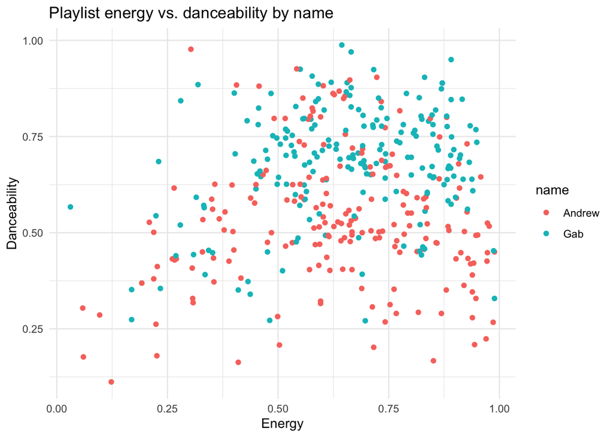

```r
# Inspecting danceability, going to bind our data together
danceable_tracks <- audio_feat %>%
  select(track.name, danceability, energy, name)

danceable_tracks_g <- gab_feat %>% select(track.name, danceability, energy, name) %>%
  rbind(danceable_tracks) %>%
  arrange(danceability)

# Create a scatterplot of energy vs danceability
ggplot(data = danceable_tracks_g, aes(x = energy, y = danceability, color = name)) +
  geom_point() + labs(x = "Energy", y = "Danceability", title = "Playlist energy vs. danceability by name") + theme_minimal()
```

```r
# Group the danceable_tracks_g data frame by the "name" column and calculate the mean danceability and energy for each group
danceable_tracks_g %>%
  group_by(name) %>%
  summarise(mean_d = mean(danceability), mean_e = mean(energy))
```

```
## # A tibble: 2 × 3
##   name   mean_d mean_e
##   <chr>   <dbl>  <dbl>
## 1 Andrew  0.536  0.639
## 2 Gab     0.680  0.658
```

For example: What are the most danceable tracks in your dataset? What are some differences in the data between users (Option 1) or genres (Option 2)? **I am completely unsurprised that Gab’s playlist’s mean danceability is much higher than mine, but surprised to see that our average energies are similar.**

### **Modeling**

Create two models, a k-nearest neighbor model and a decision tree model that predict whether a track belongs to:

1. you or your partner’s collection

```r
set.seed(123)
# Split the data into a training set (75%) and a test set (25%)
data_split <- initial_split(data, prop = 0.75)

# Get the training set
data_train <- training(data_split)

# Get the test set
data_test <- testing(data_split)
```

## KNN

```r
# Preprocessing
rec <- recipe(name ~ ., data = data_train) |>
  step_dummy(all_nominal(), -all_outcomes(), one_hot = TRUE) |>
  step_normalize(all_numeric(), -all_outcomes()) |>
  prep()

# Bake the data
baked_data <- bake(rec, data_train)
baked_test <- bake(rec, data_test)

# Define model specifications
knn_spec <- nearest_neighbor() |>
  set_engine("kknn") |>
  set_mode("classification")

# Fit model to training data
knn_fit <- knn_spec %>%
  fit(name ~. , data = data_train)

set.seed(123)
# 10-fold CV on the training dataset
cv_folds <- data_train |> vfold_cv(v=5)

# Define workflow
knn_workflow <- workflow() |>
  add_model(knn_spec) |>
  add_recipe(rec)

# Fitting workflow to each of our folds
knn_res <- knn_workflow |>
  fit_resamples(
    resamples = cv_folds,
    control = control_resamples(save_pred = TRUE)
  )
# See how we did
knn_res |>
  collect_metrics()
```

```
## # A tibble: 2 × 6
##   .metric  .estimator  mean     n std_err .config
##   <chr>    <chr>      <dbl> <int>   <dbl> <chr>
## 1 accuracy binary     0.657     5  0.0319 Preprocessor1_Model1
## 2 roc_auc  binary     0.713     5  0.0383 Preprocessor1_Model1
```

```r
# Now to tune the model
knn_spec_tune <- nearest_neighbor(neighbors = tune()) |>
  set_mode("classification") |>
  set_engine("kknn")

# Define new workflow
tune_wf <- workflow() |>
  add_model(knn_spec_tune) |>
  add_recipe(rec)

# Fit the workflow on our predefined folds and hyperparameters
fit_knn_cv <- tune_wf |>
  tune_grid(cv_folds, grid = data.frame(neighbors = c(1, 5, seq(10,100,10))))

# Check the performance with collect_metrics()
metrics <- fit_knn_cv %>% collect_metrics()

#final knn wf
final_wf <- tune_wf |>
  finalize_workflow(select_best(fit_knn_cv))
final_wf
```

```
## ══ Workflow ════════════════════════════════════════════════════════════════════
## Preprocessor: Recipe
## Model: nearest_neighbor()
##
## ── Preprocessor ────────────────────────────────────────────────────────────────
## 2 Recipe Steps
##
## • step_dummy()
## • step_normalize()
##
## ── Model ───────────────────────────────────────────────────────────────────────
## K-Nearest Neighbor Model Specification (classification)
##
## Main Arguments:
##   neighbors = 30
##
## Computational engine: kknn
```

```r
#fit final wf
final_fit <- final_wf |>
  last_fit(data_split)

knn_preds <- final_fit$.predictions |> data.frame() |> mutate(model = "KNN")

final_fit |> collect_metrics()
```

```
## # A tibble: 2 × 4
##   .metric  .estimator .estimate .config
##   <chr>    <chr>          <dbl> <chr>
## 1 accuracy binary         0.67  Preprocessor1_Model1
## 2 roc_auc  binary         0.730 Preprocessor1_Model1
```

## Decision Tree

```r
#tidymodels
# model specification
dt_spec <-
  decision_tree(
    mode = 'classification',
    engine = 'rpart',
    cost_complexity = 0.1,
    tree_depth = 4,
    min_n = 11
  )

# fitting the training data
dt_fit <- dt_spec |>
  fit(name ~ ., data = data_train)
# dt workflow

dt_workflow <- workflow() |>
  add_model(dt_spec) |>
  add_recipe(rec)

# Fitting workflow to each of our folds
dt_res <- dt_workflow |>
  fit_resamples(resamples = cv_folds,
                control = control_resamples(save_pred = TRUE))
# See how we did
dt_res |>
  collect_metrics()
```

```
## # A tibble: 2 × 6
##   .metric  .estimator  mean     n std_err .config
##   <chr>    <chr>      <dbl> <int>   <dbl> <chr>
## 1 accuracy binary     0.777     5  0.0292 Preprocessor1_Model1
## 2 roc_auc  binary     0.779     5  0.0243 Preprocessor1_Model1
```

```r
# Now to tune the model
dt_spec_tune <- decision_tree(
  tree_depth = tune(),
  cost_complexity = tune(),
  min_n = tune()
) |>
  set_mode("classification") |>
  set_engine("rpart")

# Looking at hyperparameters
tree_grid <-
  grid_regular(cost_complexity(), tree_depth(), min_n(), levels = 5)

# Define new workflow
dt_tune_wf <- workflow() |>
  add_model(dt_spec_tune) |>
  add_recipe(rec)

# Defining cv for tuning
tree_cv = data_train |> vfold_cv(v = 5)
tree_cv
```

```
## #  5-fold cross-validation
## # A tibble: 5 × 2
##   splits           id
##   <list>           <chr>
## 1 <split [240/60]> Fold1
## 2 <split [240/60]> Fold2
## 3 <split [240/60]> Fold3
## 4 <split [240/60]> Fold4
## 5 <split [240/60]> Fold5
```

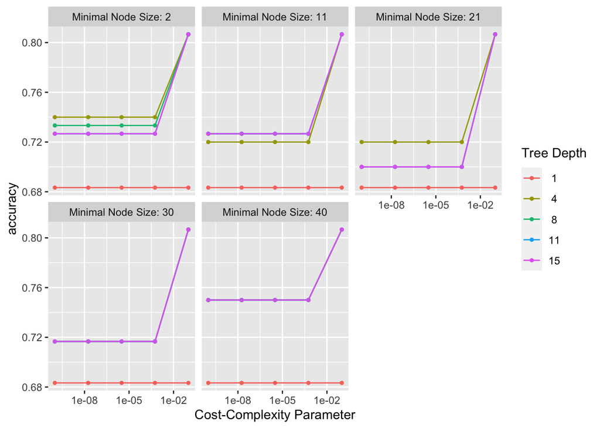

```r
# Tuning
tree_rs <- tune_grid(
  dt_spec_tune,
  name ~ .,
  resamples = tree_cv,
  grid = tree_grid,
  metrics = metric_set(accuracy)
)

# Visualizing our predictions
autoplot(tree_rs)
```

```r
# Selecting the best model
show_best(tree_rs)
```

```
## # A tibble: 5 × 9
##   cost_complexity tree_depth min_n .metric  .estim…¹  mean     n std_err .config
##             <dbl>      <int> <int> <chr>    <chr>    <dbl> <int>   <dbl> <chr>
## 1             0.1          4     2 accuracy binary   0.807     5  0.0245 Prepro…
## 2             0.1          8     2 accuracy binary   0.807     5  0.0245 Prepro…
## 3             0.1         11     2 accuracy binary   0.807     5  0.0245 Prepro…
## 4             0.1         15     2 accuracy binary   0.807     5  0.0245 Prepro…
## 5             0.1          4    11 accuracy binary   0.807     5  0.0245 Prepro…
## # … with abbreviated variable name ¹.estimator
```

```r
select_best(tree_rs)
```

```
## # A tibble: 1 × 4
##   cost_complexity tree_depth min_n .config
##             <dbl>      <int> <int> <chr>
## 1             0.1          4     2 Preprocessor1_Model010
```

```r
# Now to finalize, train and test our best model
final_tree <- finalize_model(dt_spec_tune, select_best(tree_rs))

final_tree_fit <- last_fit(final_tree, name ~ ., data_split)

# A look at the predictions
pred_dt <- final_tree_fit$.predictions |> data.frame() |> mutate(model = "Decision Tree")
```

```r
#tidymodels
# model specification
bagdt_spec <-
  bag_tree(
    mode = 'classification',
    cost_complexity = 0.1,
    tree_depth = 4,
    min_n = 11
  ) |>
  set_engine("rpart", times= 500)

# fitting the training data
bag_dtfit <- bagdt_spec |>
  fit(name ~ ., data = data_train)
# dt workflow

bag_dt_workflow <- workflow() |>
  add_model(bagdt_spec) |>
  add_recipe(rec)

# Fitting workflow to each of our folds
bagdt_res <- bag_dt_workflow |>
  fit_resamples(resamples = cv_folds,
                control = control_resamples(save_pred = TRUE))
# See how we did
bagdt_res |>
  collect_metrics()
```

```
## # A tibble: 2 × 6
##   .metric  .estimator  mean     n std_err .config
##   <chr>    <chr>      <dbl> <int>   <dbl> <chr>
## 1 accuracy binary     0.803     5  0.0143 Preprocessor1_Model1
## 2 roc_auc  binary     0.846     5  0.0186 Preprocessor1_Model1
```

```r
# Now to tune the model
bagdt_spec_tune <- bag_tree(
  tree_depth = tune(),
  cost_complexity = tune(),
  min_n = tune()
) |>
  set_mode("classification") |>
  set_engine("rpart", times = 500)

# Looking at hyperparameters
bagdt_grid <-
  grid_regular(cost_complexity(), tree_depth(), min_n(), levels = 5)

# Define new workflow
bagdt_tune_wf <- workflow() |>
  add_model(bagdt_spec_tune) |>
  add_recipe(rec)

# Defining cv for tuning
bagdt_cv = data_train |> vfold_cv(v = 5)
bagdt_cv
```

```
## #  5-fold cross-validation
## # A tibble: 5 × 2
##   splits           id
##   <list>           <chr>
## 1 <split [240/60]> Fold1
## 2 <split [240/60]> Fold2
## 3 <split [240/60]> Fold3
## 4 <split [240/60]> Fold4
## 5 <split [240/60]> Fold5
```

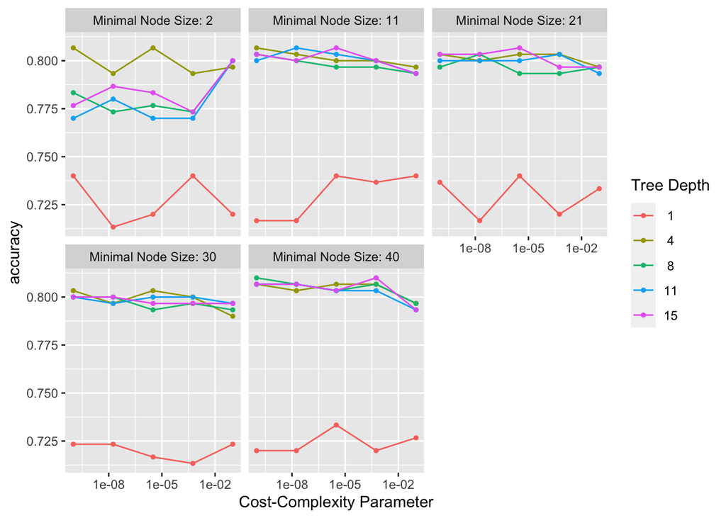

```r
# Tuning
doParallel::registerDoParallel()
bagdt_rs <- tune_grid(
  bagdt_spec_tune,
  name ~ .,
  resamples = bagdt_cv,
  grid = bagdt_grid,
  metrics = metric_set(accuracy)
)

# Visualizing our predictions
autoplot(bagdt_rs)
```

```r
# Selecting the best model
show_best(bagdt_rs)
```

```
## # A tibble: 5 × 9
##   cost_complexity tree_depth min_n .metric  .estim…¹  mean     n std_err .config
##             <dbl>      <int> <int> <chr>    <chr>    <dbl> <int>   <dbl> <chr>
## 1    0.0000000001          8    40 accuracy binary   0.81      5  0.0227 Prepro…
## 2    0.000562             15    40 accuracy binary   0.81      5  0.0227 Prepro…
## 3    0.0000000001          4     2 accuracy binary   0.807     5  0.0201 Prepro…
## 4    0.00000316            4     2 accuracy binary   0.807     5  0.0172 Prepro…
## 5    0.0000000001          4    11 accuracy binary   0.807     5  0.0194 Prepro…
## # … with abbreviated variable name ¹.estimator
```

```r
select_best(bagdt_rs)
```

```
## # A tibble: 1 × 4
##   cost_complexity tree_depth min_n .config
##             <dbl>      <int> <int> <chr>
## 1    0.0000000001          8    40 Preprocessor1_Model111
```

```r
# Now to finalize, train and test our best model
bagdt_final <- finalize_model(bagdt_spec_tune, select_best(bagdt_rs))

final_dt_fit <- last_fit(bagdt_final, name ~ ., data_split)

# A look at the predictions
pred_bdt <- final_dt_fit$.predictions |> data.frame() |>
  mutate(model = "Bagged Decision Tree")

final_dt_fit |> collect_metrics()
```

```
## # A tibble: 2 × 4
##   .metric  .estimator .estimate .config
##   <chr>    <chr>          <dbl> <chr>
## 1 accuracy binary         0.79  Preprocessor1_Model1
## 2 roc_auc  binary         0.856 Preprocessor1_Model1
```

## Random Forest

```r
#tidymodels
# model specification
randf_spec <-
  rand_forest(
    mode = 'classification',
    mtry = 3,
    trees = 500,
    min_n = 11
  ) |>
  set_engine("ranger")

# fitting the training data
randf_fit <- randf_spec |>
  fit(name ~ ., data = data_train)
# dt workflow

randf_workflow <- workflow() |>
  add_model(randf_spec) |>
  add_recipe(rec)

# Fitting workflow to each of our folds
randf_res <- randf_workflow |>
  fit_resamples(resamples = cv_folds,
                control = control_resamples(save_pred = TRUE))
# See how we did
randf_res |>
  collect_metrics()
```

```
## # A tibble: 2 × 6
##   .metric  .estimator  mean     n std_err .config
##   <chr>    <chr>      <dbl> <int>   <dbl> <chr>
## 1 accuracy binary     0.793     5  0.0251 Preprocessor1_Model1
## 2 roc_auc  binary     0.857     5  0.0242 Preprocessor1_Model1
```

```r
# Now to tune the model
randf_spec_tune <- rand_forest(
  trees = tune(),
  mtry = tune(),
  min_n = tune()
) |>
  set_mode("classification") |>
  set_engine("ranger")

# Looking at hyperparameters
randf_grid <-
  grid_regular(trees(), min_n(), mtry(range(1:13)), levels = 5)

# Define new workflow
randf_tune_wf <- workflow() |>
  add_model(randf_spec_tune) |>
  add_recipe(rec)

# Defining cv for tuning
randf_cv = data_train |> vfold_cv(v = 5)
randf_cv
```

```
## #  5-fold cross-validation
## # A tibble: 5 × 2
##   splits           id
##   <list>           <chr>
## 1 <split [240/60]> Fold1
## 2 <split [240/60]> Fold2
## 3 <split [240/60]> Fold3
## 4 <split [240/60]> Fold4
## 5 <split [240/60]> Fold5
```

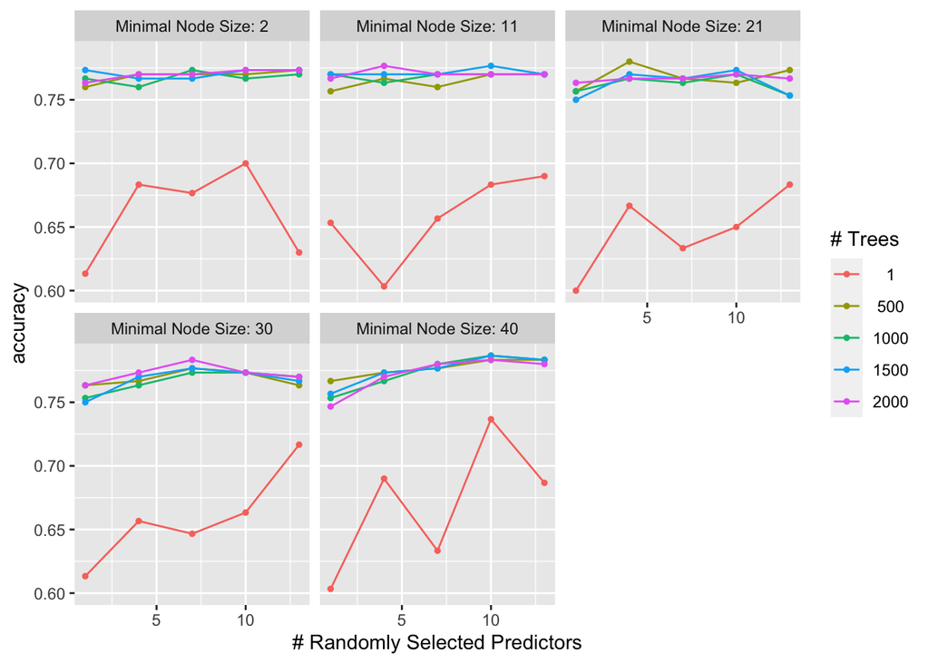

```r
# Tuning
doParallel::registerDoParallel()
randf_rs <- tune_grid(
  randf_spec_tune,
  name ~ .,
  resamples = randf_cv,
  grid = randf_grid,
  metrics = metric_set(accuracy)
)

# Visualizing our predictions
autoplot(randf_rs)
```

```r
# Selecting the best model
show_best(randf_rs)
```

```
## # A tibble: 5 × 9
##    mtry trees min_n .metric  .estimator  mean     n std_err .config
##   <int> <int> <int> <chr>    <chr>      <dbl> <int>   <dbl> <chr>
## 1    10  1000    40 accuracy binary     0.787     5  0.0276 Preprocessor1_Model…
## 2    10  1500    40 accuracy binary     0.787     5  0.0276 Preprocessor1_Model…
## 3     7  2000    30 accuracy binary     0.783     5  0.0284 Preprocessor1_Model…
## 4    10   500    40 accuracy binary     0.783     5  0.0269 Preprocessor1_Model…
## 5    10  2000    40 accuracy binary     0.783     5  0.0269 Preprocessor1_Model…
```

```r
select_best(randf_rs)
```

```
## # A tibble: 1 × 4
##    mtry trees min_n .config
##   <int> <int> <int> <chr>
## 1    10  1000    40 Preprocessor1_Model098
```

```r
# Now to finalize, train and test our best model
randf_final <- finalize_model(randf_spec_tune, select_best(randf_rs))

randf_finalfit <- last_fit(randf_final, name ~ ., data_split)

# A look at the predictions
pred_rf <- randf_finalfit$.predictions |> data.frame() |> mutate(model = "Random Forest")

randf_finalfit |> collect_metrics()
```

```
## # A tibble: 2 × 4
##   .metric  .estimator .estimate .config
##   <chr>    <chr>          <dbl> <chr>
## 1 accuracy binary         0.79  Preprocessor1_Model1
## 2 roc_auc  binary         0.881 Preprocessor1_Model1
```

```r
# Comparing accuracy
pred_table <- rbind(pred_bdt, pred_dt, pred_rf, knn_preds)

# Collect metrics for each model
knn_metrics <- final_fit %>% collect_metrics()
dt_metrics <- final_tree_fit %>% collect_metrics()
bagged_tree_metrics <- final_dt_fit %>% collect_metrics()
randf_metrics <- randf_finalfit %>% collect_metrics()

# Combine metrics into a single table
metric_table <- rbind(
  data.frame(Model = "KNN", knn_metrics),
  data.frame(Model = "Decision Tree", dt_metrics),
  data.frame(Model = "Bagged Tree", bagged_tree_metrics),
  data.frame(Model = "Random Forest", randf_metrics)
)

# Print the table
metric_table |> filter(.metric == "accuracy") |>
  arrange(desc(.estimate))
```

```
##           Model  .metric .estimator .estimate              .config
## 1   Bagged Tree accuracy     binary      0.79 Preprocessor1_Model1
## 2 Random Forest accuracy     binary      0.79 Preprocessor1_Model1
## 3 Decision Tree accuracy     binary      0.78 Preprocessor1_Model1
## 4           KNN accuracy     binary      0.67 Preprocessor1_Model1
```

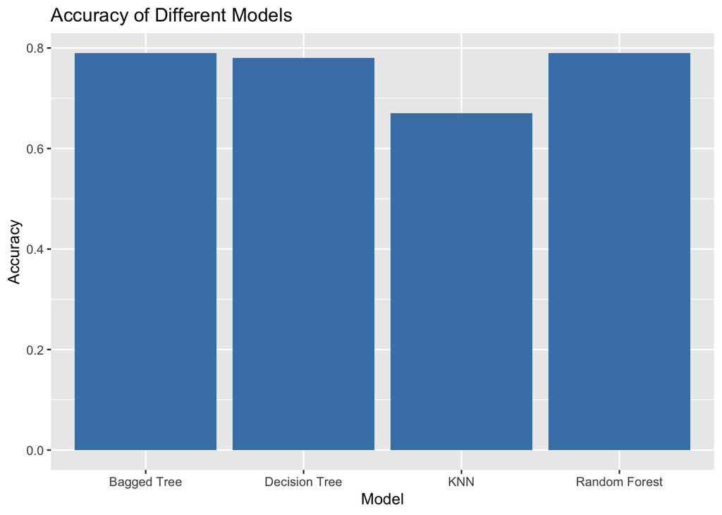

```r
# Visualizing the model performance

# Create a data frame with model names and accuracy
accuracy_data <- metric_table %>%
  filter(.metric == "accuracy") %>%
  select(Model, Accuracy = .estimate)

# Create the bar chart
ggplot(accuracy_data, aes(x = Model, y = Accuracy)) +
  geom_bar(stat = "identity", fill = "steelblue") +
  labs(title = "Accuracy of Different Models",
       x = "Model",
       y = "Accuracy")
```

Create four final candidate models:

1. k-nearest neighbor
2. decision tree
3. bagged tree
   - bag_tree()
   - Use the “times =” argument when setting the engine during model specification to specify the number of trees. The rule of thumb is that 50-500 trees is usually sufficient. The bottom of that range should be sufficient here.
4. random forest
   - rand_forest()
   - m_try() is the new hyperparameter of interest for this type of model. Make sure to include it in your tuning process

Go through the modeling process for each model:

Preprocessing. You can use the same recipe for all the models you create.

Resampling. Make sure to use appropriate resampling to select the best version created by each algorithm.

Tuning. Find the best values for each hyperparameter (within a reasonable range).

Compare the performance of the four final models you have created.

Use appropriate performance evaluation metric(s) for this classification task. A table would be a good way to display your comparison. Use at least one visualization illustrating your model results.